COMBINED REPORT

# OncoProfiling Multi-Agent Analysis

Self-contained research report · generated 2026-08-13 12:44:34 EDT

## Run summary

| Agent | Status | Rows | Plot |
| --- | --- | --- | --- |
| **GO** | Completed | 14 | Available |

PROVENANCE

## Input and run identity

| Workflow | biomarker |
| --- | --- |
| Input file | uveitis-PIIS0002939421000271-deg.txt |
| Input MD5 | e80b840cc8e90f5de2c8bd022bfbc016 |
| Input size (bytes) | 2880 |
| Rows used | 180 |
| Columns | 1 |
| Header detected | FALSE |
| Run started | 2026-08-13 12:44:04 EDT |
| Run finished | 2026-08-13 12:44:34 EDT |
| Report generated | 2026-08-13 12:44:34 EDT |

### Analysis configuration

| Gene group | all |
| --- | --- |
| Protein-coding only | FALSE |
| Adjusted p/FDR cutoff | 0.05 |
| Absolute effect cutoff | 1 |
| Maximum genes | 2000 |

IDENTIFIER QUALITY

## Gene mapping summary

| Identifier type | ensembl |
| --- | --- |
| Unique inputs | 180 |
| Mapped inputs | 137 |
| Unique HGNC symbols | 137 |
| Unmapped inputs | 43 |
| Mapping rate | 76.1% |
| Duplicate mappings removed | 0 |
| Unmapped examples | ENSG00000280800, ENSG00000099725, ENSG00000131002, ENSG00000215580, ENSG00000241859, ENSG00000239265, ENSG00000225492, ENSG00000274173 |

INTERPRETATION STATE

## Observed results and local AI

| State | Biological interpretation generated locally with llama3.1:8b |
| --- | --- |
| Source | ollama |
| Model | llama3.1:8b |
| JSON contract | 3.2-observed-interpretation |

Observed-result bullets are computed deterministically from saved result tables. Local AI text is an interpretive layer and cannot change those observations.

BIOMARKER DISCOVERY

## Biomarker evidence and interpretation

Each agent shows deterministic observed results before any interpretive context.

Gene list

### GO Analysis

14 rows

Enriched Gene Ontology biological-process terms.

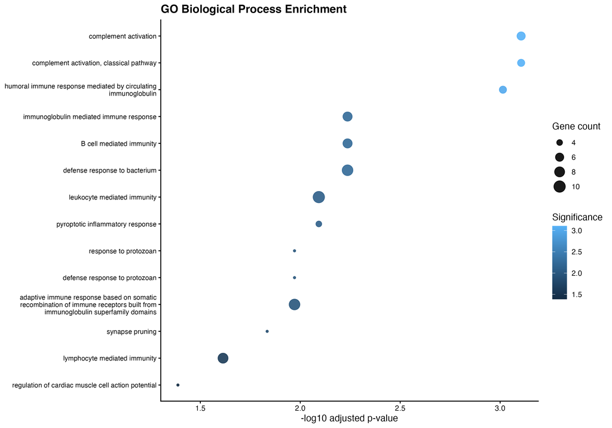

GO visualization

#### Full-precision result preview

| ID | Description | GeneRatio | BgRatio | RichFactor | FoldEnrichment | zScore | pvalue | p.adjust | qvalue | geneID | Count |
| --- | --- | --- | --- | --- | --- | --- | --- | --- | --- | --- | --- |
| GO:0006956 | complement activation | 6/92 | 65/18842 | 0.09 | 18.91 | 10.13 | 7.53e-07 | 7.85e-04 | 7.22e-04 | IGHG4/C1QB/C1QA/SERPING1/C4BPA/C1QC | 6.00 |
| GO:0006958 | complement activation, classical pathway | 5/92 | 39/18842 | 0.13 | 26.26 | 11.06 | 1.26e-06 | 7.85e-04 | 7.22e-04 | IGHG4/C1QB/C1QA/C4BPA/C1QC | 5.00 |
| GO:0002455 | humoral immune response mediated by circulating immunoglobulin | 5/92 | 44/18842 | 0.11 | 23.27 | 10.36 | 2.32e-06 | 9.68e-04 | 8.91e-04 | IGHG4/C1QB/C1QA/C4BPA/C1QC | 5.00 |
| GO:0016064 | immunoglobulin mediated immune response | 7/92 | 172/18842 | 0.04 | 8.34 | 6.77 | 2.13e-05 | 5.80e-03 | 5.34e-03 | IGHG4/FCGR1A/C1QB/C1QA/C4BPA/C1QC/IGHV3-35 | 7.00 |
| GO:0019724 | B cell mediated immunity | 7/92 | 177/18842 | 0.04 | 8.10 | 6.65 | 2.57e-05 | 5.80e-03 | 5.34e-03 | IGHG4/FCGR1A/C1QB/C1QA/C4BPA/C1QC/IGHV3-35 | 7.00 |
| GO:0042742 | defense response to bacterium | 9/92 | 322/18842 | 0.03 | 5.72 | 5.99 | 2.78e-05 | 5.80e-03 | 5.34e-03 | IGHG4/GBP1/SLAMF8/GBP6/HP/NAIP/SIGLEC16/ANXA3/GBP5 | 9.00 |
| GO:0002443 | leukocyte mediated immunity | 10/92 | 429/18842 | 0.02 | 4.77 | 5.54 | 4.60e-05 | 8.08e-03 | 7.43e-03 | IGHG4/FCGR1A/C1QB/C1QA/CD274/C4BPA/C1QC/IGHV3-35/ANXA3/CD177 | 10.00 |
| GO:0070269 | pyroptotic inflammatory response | 4/92 | 42/18842 | 0.10 | 19.51 | 8.41 | 5.17e-05 | 8.08e-03 | 7.43e-03 | GBP1/IFI27/NAIP/GBP5 | 4.00 |
| GO:0001562 | response to protozoan | 3/92 | 18/18842 | 0.17 | 34.13 | 9.85 | 8.72e-05 | 1.07e-02 | 9.83e-03 | GBP1/GBP6/BATF2 | 3.00 |
| GO:0042832 | defense response to protozoan | 3/92 | 18/18842 | 0.17 | 34.13 | 9.85 | 8.72e-05 | 1.07e-02 | 9.83e-03 | GBP1/GBP6/BATF2 | 3.00 |
| GO:0002460 | adaptive immune response based on somatic recombination of immune receptors built from immunoglobulin superfamily domains | 9/92 | 377/18842 | 0.02 | 4.89 | 5.34 | 9.40e-05 | 1.07e-02 | 9.83e-03 | IGHG4/FCGR1A/C1QB/C1QA/CD274/C4BPA/IL27/C1QC/IGHV3-35 | 9.00 |
| GO:0098883 | synapse pruning | 3/92 | 21/18842 | 0.14 | 29.26 | 9.08 | 1.41e-04 | 1.46e-02 | 1.35e-02 | C1QB/C1QA/C1QC | 3.00 |
| GO:0002449 | lymphocyte mediated immunity | 8/92 | 339/18842 | 0.02 | 4.83 | 4.99 | 2.53e-04 | 2.44e-02 | 2.24e-02 | IGHG4/FCGR1A/C1QB/C1QA/CD274/C4BPA/C1QC/IGHV3-35 | 8.00 |
| GO:0098901 | regulation of cardiac muscle cell action potential | 3/92 | 31/18842 | 0.10 | 19.82 | 7.35 | 4.59e-04 | 4.09e-02 | 3.77e-02 | FGF13/NOS1AP/ANK2 | 3.00 |

#### Observed results · deterministic

- complement activation: RichFactor=0.09231, FoldEnrichment=18.91, zScore=10.13, pvalue=0.0000007528, p.adjust=0.0007848, qvalue=0.0007224
- complement activation, classical pathway: RichFactor=0.1282, FoldEnrichment=26.26, zScore=11.06, pvalue=0.000001256, p.adjust=0.0007848, qvalue=0.0007224
- humoral immune response mediated by circulating immunoglobulin: RichFactor=0.1136, FoldEnrichment=23.27, zScore=10.36, pvalue=0.000002323, p.adjust=0.0009681, qvalue=0.0008911

#### Interpretive context

The GO enrichment analysis reveals a significant over-representation of immune-related processes, including complement activation, classical pathway, humoral immune response mediated by circulating immunoglobulin, and B cell mediated immunity. The top enriched terms are complement activation (RichFactor: 0.0923, FoldEnrichment: 18.905) and complement activation, classical pathway (RichFactor: 0.1282, FoldEnrichment: 26.257).

General biological context: Immune and inflammatory programs generally describe cytokine signaling, leukocyte-associated responses, and host-defense processes. These descriptions are general annotations of the named result labels, not additional measurements, causal conclusions, or clinical claims from this dataset.

##### Cancer relevance

Cannot be determined from the supplied result data alone.

##### Limitations

- The enrichment analysis does not imply pathway activation or clinical effectiveness. The significance of these findings cannot be determined without additional context and experimental validation.

METHODS AND VERSIONS

## Reproducible environment

Human identifier mapping uses the installed org.Hs.eg.db annotation. Agent-specific tests and thresholds are recorded in saved outputs and configuration above.

| component | version |
| --- | --- |
| R | 4.6.1 |
| shiny | 1.14.0 |
| clusterProfiler | 4.20.0 |
| org.Hs.eg.db | 3.23.1 |
| ReactomePA | 1.56.0 |
| STRINGdb | 2.24.0 |
| msigdbr | 26.1.0 |
| GSVA | 2.6.2 |
| immunedeconv | 2.1.4 |
| ggplot2 | 4.0.3 |
| jsonlite | 2.0.0 |
| httr2 | 1.3.0 |

LIMITATIONS

## Responsible interpretation

- Enrichment is over-representation and does not prove pathway activation or causality.
- Network centrality does not establish functional importance.
- GSVA scores are relative sample-level estimates; immune deconvolution is estimated composition.
- Drug-response ranks do not establish mechanism, clinical efficacy, dose, or patient suitability.
- Annotation databases and installed packages are version-dependent. Unmapped genes are excluded and summarized above.
- Results require independent statistical, biological and clinical review.

ARTIFACT MANIFEST

## Files represented in this report

| agent | artifact | file | exists | size_bytes | md5 | rows |
| --- | --- | --- | --- | --- | --- | --- |
| go | csv | go_results.csv | TRUE | 3,197.00 | b4569d6076f5969953950d94a6181b0f | 14.00 |
| go | plot | go_biological_process_dotplot.png | TRUE | 194,519.00 | 8a9ade8f9dfa0730c44c000b7cf2f3fe |  |